# R Assignment - Practical Machine Learning Week 4

N

July 17, 2018

## Data Preparation

We need to use the training set to create a classification of the “classe” variable and apply it to the testing set.

Set up codes needed and the local space

```r
library(caret); library(ggplot2);
setwd("C:/Nick/07 R/R User Notes/Practical Machine Learning/Assignment")
```

Now import the two initial datasets:

```r
inSet<-read.csv("C:/Nick/07 R/R User Notes/Practical Machine Learning/Assignment/3pml-training.csv")
outSet<-read.csv("C:/Nick/07 R/R User Notes/Practical Machine Learning/Assignment/4pml-testing.csv")
```

Take a look at the intitial data

```r
head(inSet)
```

[output not shown]

**Keep only variables that are not blank or NA. Classe is the response variable to model.** Some variables are very low response and correlated with the “New_window” variable. We can filter the records later to see if the prediction improves. This is since the test set does not include any of the additional data

```r
inSet1<-inSet[,c(6:7,8:11, 37:49, 60:68,84:86,102,113:124,140,151:160)]
t_<-colnames(inSet1)
t_  #check the columns required are included
```

```
##  [1] "new_window"           "num_window"           "roll_belt"
##  [4] "pitch_belt"           "yaw_belt"             "total_accel_belt"
##  [7] "gyros_belt_x"         "gyros_belt_y"         "gyros_belt_z"
## [10] "accel_belt_x"         "accel_belt_y"         "accel_belt_z"
## [13] "magnet_belt_x"        "magnet_belt_y"        "magnet_belt_z"
## [16] "roll_arm"             "pitch_arm"            "yaw_arm"
## [19] "total_accel_arm"      "gyros_arm_x"          "gyros_arm_y"
## [22] "gyros_arm_z"          "accel_arm_x"          "accel_arm_y"
## [25] "accel_arm_z"          "magnet_arm_x"         "magnet_arm_y"
## [28] "magnet_arm_z"         "roll_dumbbell"        "pitch_dumbbell"
## [31] "yaw_dumbbell"         "total_accel_dumbbell" "gyros_dumbbell_x"
## [34] "gyros_dumbbell_y"     "gyros_dumbbell_z"     "accel_dumbbell_x"
## [37] "accel_dumbbell_y"     "accel_dumbbell_z"     "magnet_dumbbell_x"
## [40] "magnet_dumbbell_y"    "magnet_dumbbell_z"    "roll_forearm"
## [43] "pitch_forearm"        "yaw_forearm"          "total_accel_forearm"
## [46] "gyros_forearm_x"      "gyros_forearm_y"      "gyros_forearm_z"
## [49] "accel_forearm_x"      "accel_forearm_y"      "accel_forearm_z"
## [52] "magnet_forearm_x"     "magnet_forearm_y"     "magnet_forearm_z"
## [55] "classe"
```

Create some plots of the variables to see the kind of pre-processing required

Rotating through the variable numbers to see if there was anything interesting (only made it through the first 7 :)

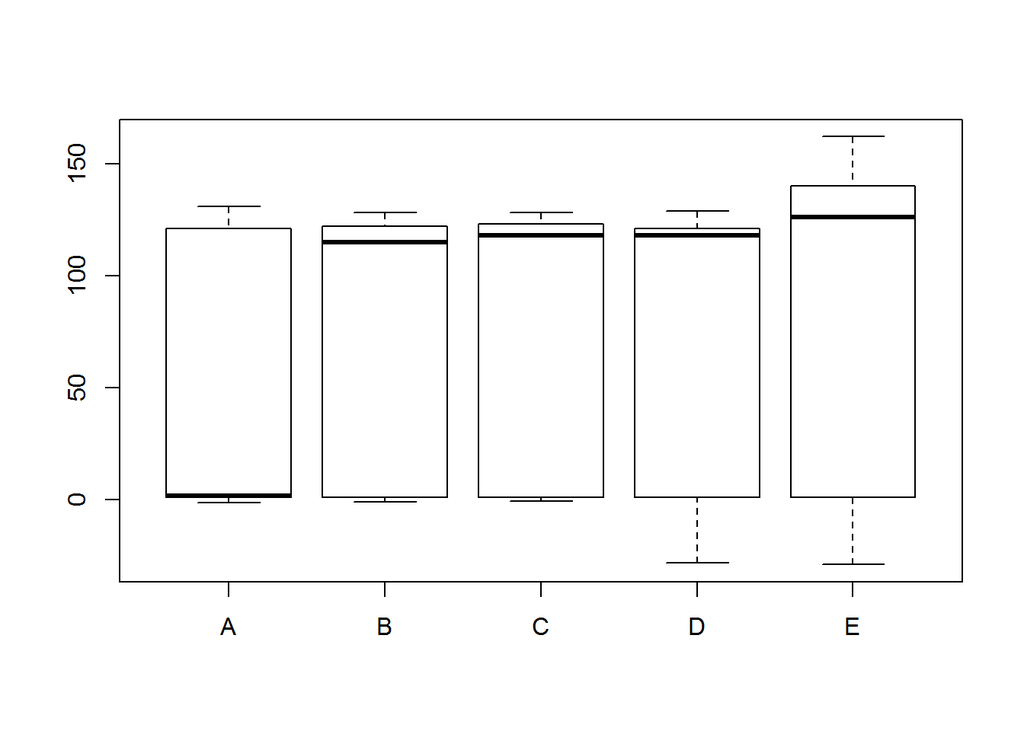

```r
plot(inSet1$classe,inSet1[,3],pch=19,cex=0.5)
```

The above plot shows skew in the data that needs to be resolved.

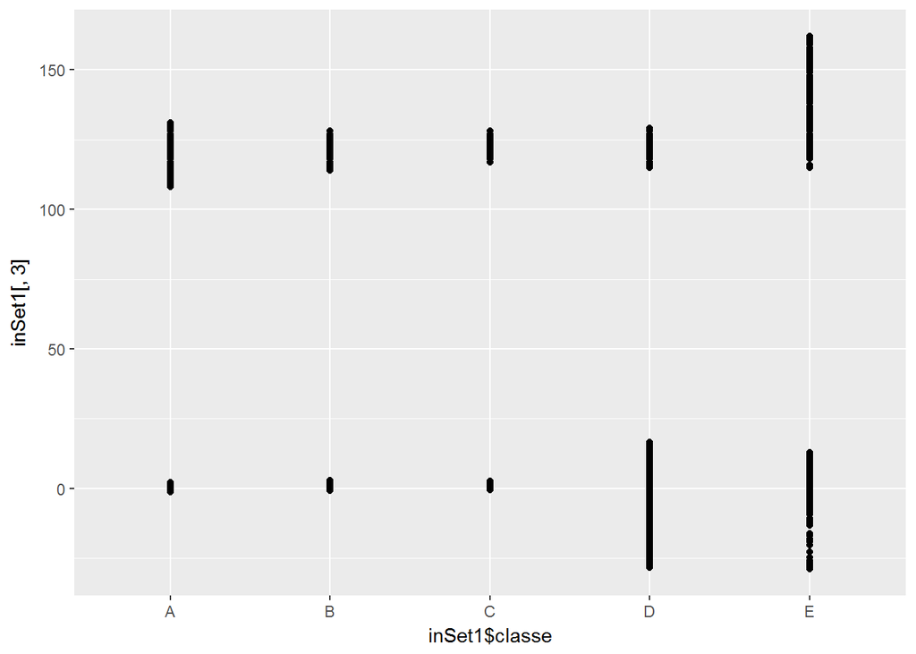

```r
qplot(inSet1$classe,inSet1[,3],data=inSet1)
```

**As an example item 3 “roll_belt” shows skew in the data. We need to centralise the data and scale prior to modelling.**

Now create the test and train sets for analysis:

```r
set.seed(32343)                     #set sampling seed...
inTrain<-createDataPartition(y=inSet1$classe,p=0.75,list=FALSE) #split the data set around 75/25
training<-inSet1[inTrain,]                  #create train dataset
testing<-inSet1[-inTrain,]                  #create test dataset
dim(training); dim(testing);                    #assess the sample data
```

[output not shown]

Filter the data for the “new_window” variable to create a ‘simpler’ version of the data without the sparse information:

```r
training_filter<-training[training[,1]=="no",]
testing_filter<-testing[testing[,1]=="no",]
dim(training_filter); dim(testing_filter);
```

[output not shown]

## Modelling

Given the supervised classification, I have selected the GBM model structure. An alternative could be random forrest, but i believe weak learners of a GBM will treat the finer grade boundaries of the continous data very well. RF or alternative methods could be tried if the GBM does not perform well.

Version 1: GBM Full data: centre and scale pre-processing

```r
mod1_full<-train(classe~.,data=training,preProcess=c("center","scale"),method="gbm")
```

```r
mod1_filter<-train(classe~.,data=training,preProcess=c("center","scale"),method="gbm")
```

Create the predictions

```r
pred1_full<-predict(testing,mod1_full$finalModel)
pred1_full<-predict(mod1_full,testing)
pred1_filter<-predict(mod1_filter,testing_filter)
```

Run the confusion matrix

```r
confusionMatrix(pred1_full,testing$classe)
confusionMatrix(pred1_filter,testing_filter$classe)
```

[output not shown]

# Results

Apply the final predictions to the test set for both the full and the filtered models:

```r
ANSWERS<-predict(mod1_full,outSet)
ANSWERS_filter<-predict(mod1_filter,outSet)
ANSWERS
ANSWERS_filter
```

[output not shown]

## Conclusion

1. Given the 98% accuracy of both models on the test portion of the training set, on a sample of 20 we could expect above 19/20 correct in each case.
2. The additional sparse data is a very small portion of the full model. It will have little influense on the modelling structure and as a result will still train well on data that does not contain the additional information.